# R 연습문제

Joey Choi

2019 6 10

##연습문제

#1 mpg 데이터의 cty(도시 연비)와 hwy(고속도로 연비) 간에 어떤 관계가 있는지 알아보려고 합니다. x축은 cty, y축은 hwy로 된 산점도를 만들어 보세요.

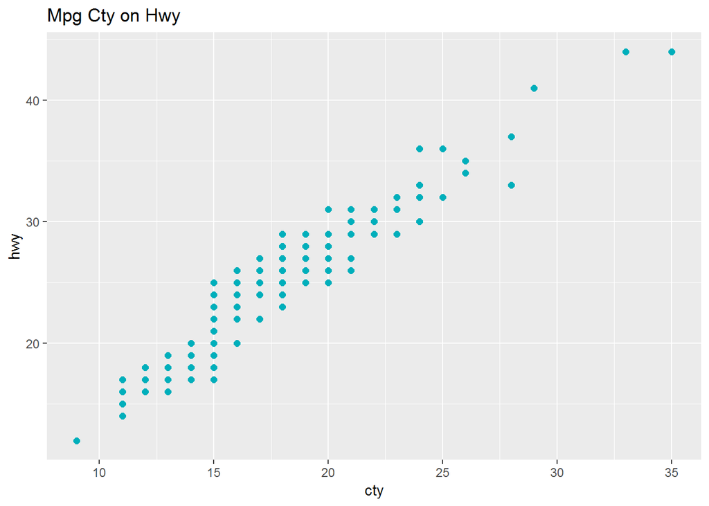

```r
library(ggplot2)
ggplot(mpg, aes(x=cty, y=hwy)) +
  geom_point(size = 2,color = "#00AFBB") +
  ggtitle("Mpg Cty on Hwy")
```

#2 미국 지역별 인구통계 정보를 담은 ggplot2 패키지의 midwest 데이터를 이용해서 전체 인구와 아시아인 인구 간에 어떤 관계가 있는지 알아보려고 합니다. #x축은 poptotal(전체 인구), y축은 popasian(아시아인 인구)으로 된 산점도를 만들어 보세요. 전체 인구는 50만 명 이하, #아시아인 인구는 1만 명 이하인 지역만 산점도에 표시되게 설정하세요. ggplot(midwest, aes(x=poptotal, y=popasian)) + geom_point()

```r
library(dplyr)
midwest_control <- midwest %>%
  filter(poptotal<=500000 & popasian <= 10000)
midwest_control
```

```
## # A tibble: 422 x 28
##      PID county state  area poptotal popdensity popwhite popblack
##    <int> <chr>  <chr> <dbl>    <int>      <dbl>    <int>    <int>
##  1   561 ADAMS  IL    0.052    66090      1271.    63917     1702
##  2   562 ALEXA~ IL    0.014    10626       759      7054     3496
##  3   563 BOND   IL    0.022    14991       681.    14477      429
##  4   564 BOONE  IL    0.017    30806      1812.    29344      127
##  5   565 BROWN  IL    0.018     5836       324.     5264      547
##  6   566 BUREAU IL    0.05     35688       714.    35157       50
##  7   567 CALHO~ IL    0.017     5322       313.     5298        1
##  8   568 CARRO~ IL    0.027    16805       622.    16519      111
##  9   569 CASS   IL    0.024    13437       560.    13384       16
## 10   570 CHAMP~ IL    0.058   173025      2983.   146506    16559
## # ... with 412 more rows, and 20 more variables: popamerindian <int>,
## #   popasian <int>, popother <int>, percwhite <dbl>, percblack <dbl>,
## #   percamerindan <dbl>, percasian <dbl>, percother <dbl>,
## #   popadults <int>, perchsd <dbl>, percollege <dbl>, percprof <dbl>,
## #   poppovertyknown <int>, percpovertyknown <dbl>, percbelowpoverty <dbl>,
## #   percchildbelowpovert <dbl>, percadultpoverty <dbl>,
## #   percelderlypoverty <dbl>, inmetro <int>, category <chr>
```

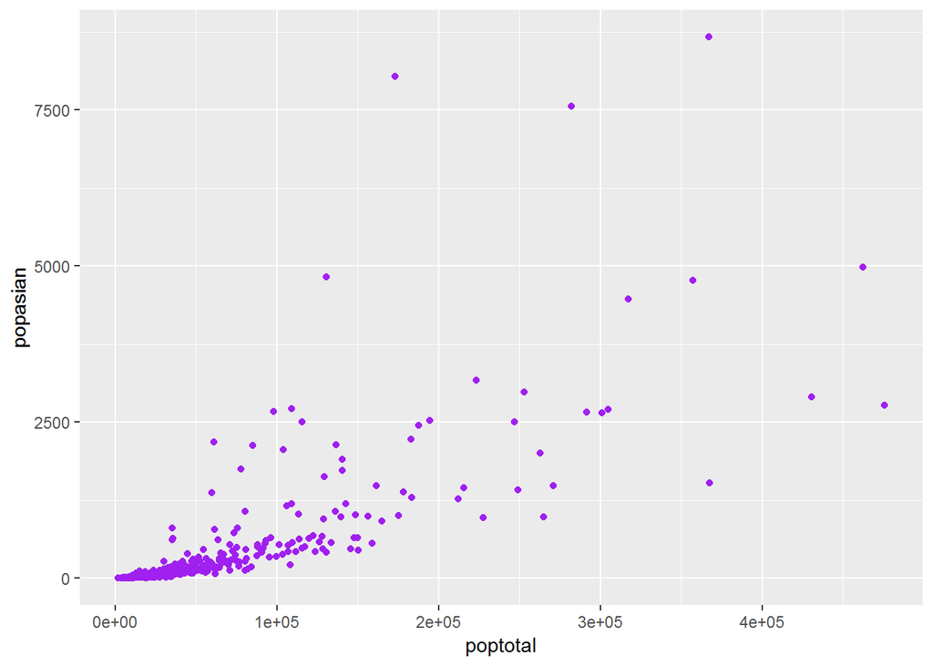

```r
ggplot(midwest_control, aes(x=poptotal, y=popasian)) +
    geom_point(color="purple")
```

#3 어떤 회사에서 생산한 “suv” 차종의 도시 연비가 높은지 알아보려고 합니다. “suv” 차종을 대상으로 평균 cty(도시 연비)가 가장 높은 회사 다섯 곳을 막대 그래프로 표현해 보세요. 막대는 연비가 높은 순으로 정렬하세요.

```r
df_suv <- mpg %>%
  filter(class=='suv') %>%
  group_by(manufacturer) %>%
  summarise(mean_cty = mean(cty)) %>%
  arrange(desc(mean_cty)) %>%
  head(5)

df_suv
```

```
## # A tibble: 5 x 2
##   manufacturer mean_cty
##   <chr>           <dbl>
## 1 subaru           18.8
## 2 toyota           14.4
## 3 nissan           13.8
## 4 jeep             13.5
## 5 mercury          13.2
```

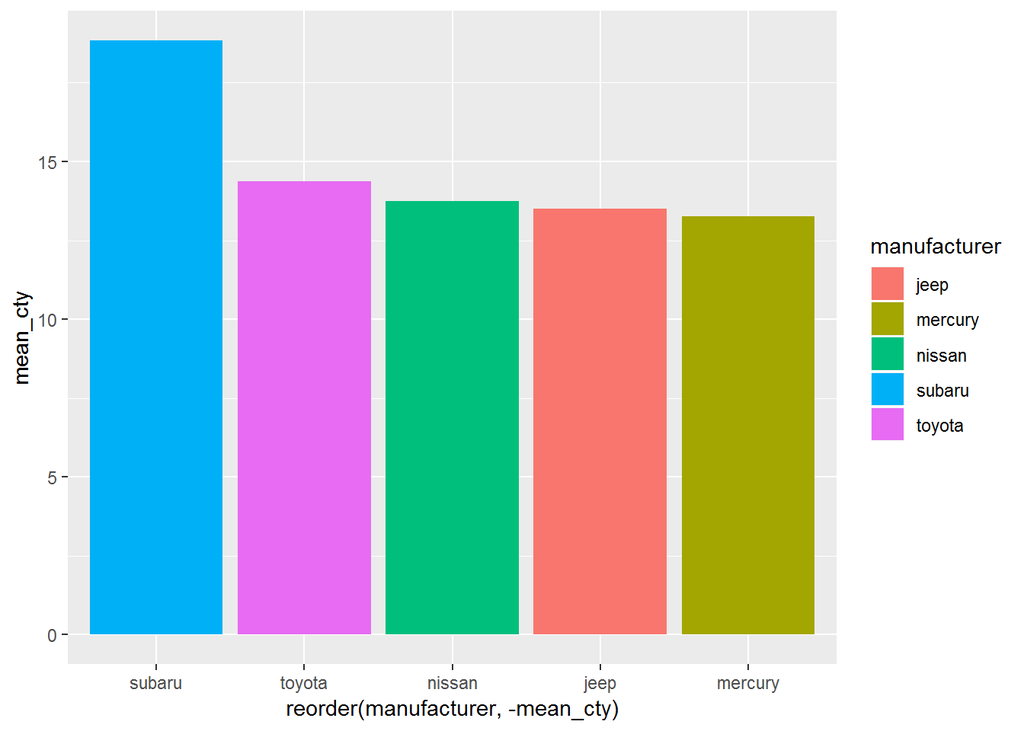

```r
ggplot(df_suv,aes(x=reorder(manufacturer, -mean_cty), y=mean_cty,
                  fill=manufacturer)) + geom_col()
```

#4 자동차 중에서 어떤 class(자동차 종류)가 가장 많은지 알아보려고 합니다. 자동차 종류별 빈도를 표현한 막대 그래프를 만들어 보세요.

```r
mpg_class <- mpg %>%
  group_by(class) %>%
  count(class)
mpg_class
```

```
## # A tibble: 7 x 2
## # Groups:   class [7]
##   class          n
##   <chr>      <int>
## 1 2seater        5
## 2 compact       47
## 3 midsize       41
## 4 minivan       11
## 5 pickup        33
## 6 subcompact    35
## 7 suv           62
```

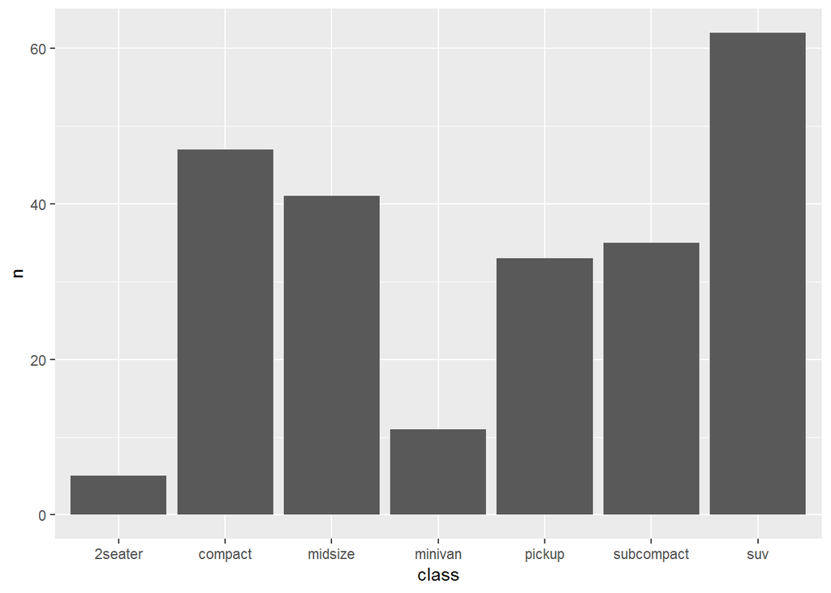

```r
ggplot(mpg_class,aes(x=class,y=n)) +
  geom_bar(stat = "identity" )
```

#5 economics 데이터를 이용해서 psavert(개인 저축률)가 시간에 따라서 어떻게 변해왔는지 알아보려고 합니다. #시간에 따른 개인 저축률의 변화를 나타낸 시계열 그래프를 만들어 보세요.

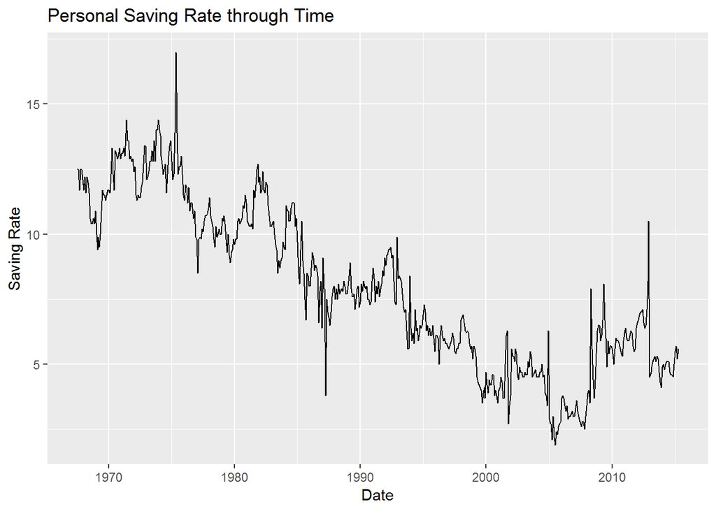

```r
psavert <- economics %>%
  select(date,psavert)
ggplot(psavert,aes(x=date , y=psavert)) +
   geom_line() +
#  geom_point(size = 0.1) +
  ggtitle("Personal Saving Rate through Time ")  + xlab("Date") + ylab("Saving Rate")
```

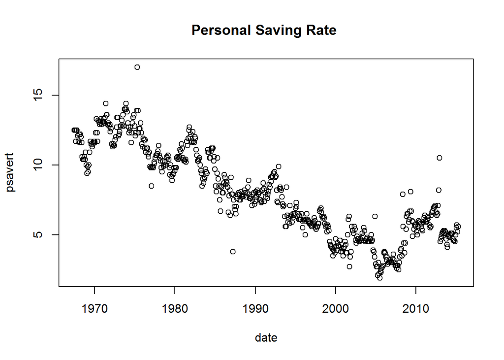

```r
plot(psavert, main="Personal Saving Rate " )
```

#6 class(자동차 종류)가 “compact”, “subcompact”, “suv”인 자동차의 #cty(도시 연비)가 어떻게 다른지 비교해보려고 합니다. 세 차종의 cty를 나타낸 상자 그림을 만들어보세요.

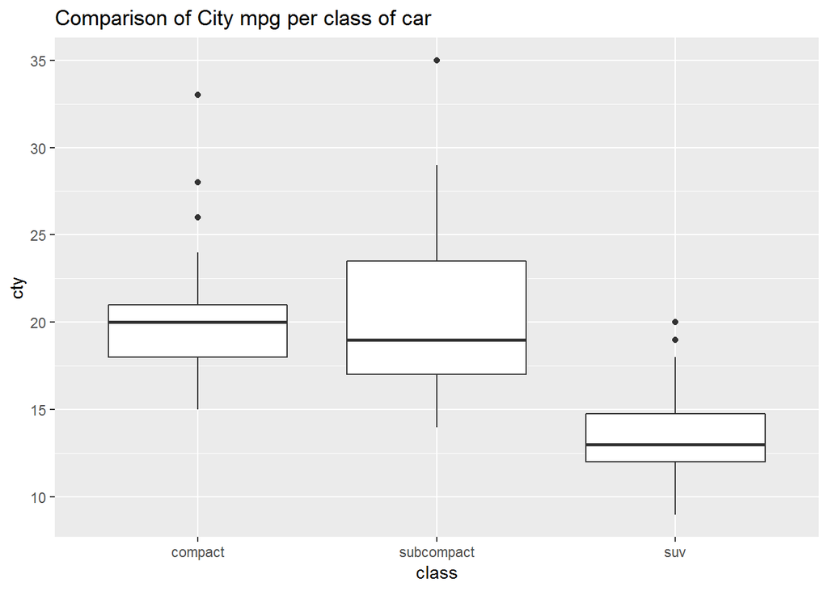

```r
mpg_compare <- mpg %>%
  filter(class == "compact" | class == "subcompact" | class == "suv") %>%
  group_by(class,cty)

ggplot(mpg_compare, aes(x=class,y=cty)) +
  geom_boxplot() + ggtitle("Comparison of City mpg per class of car")
```

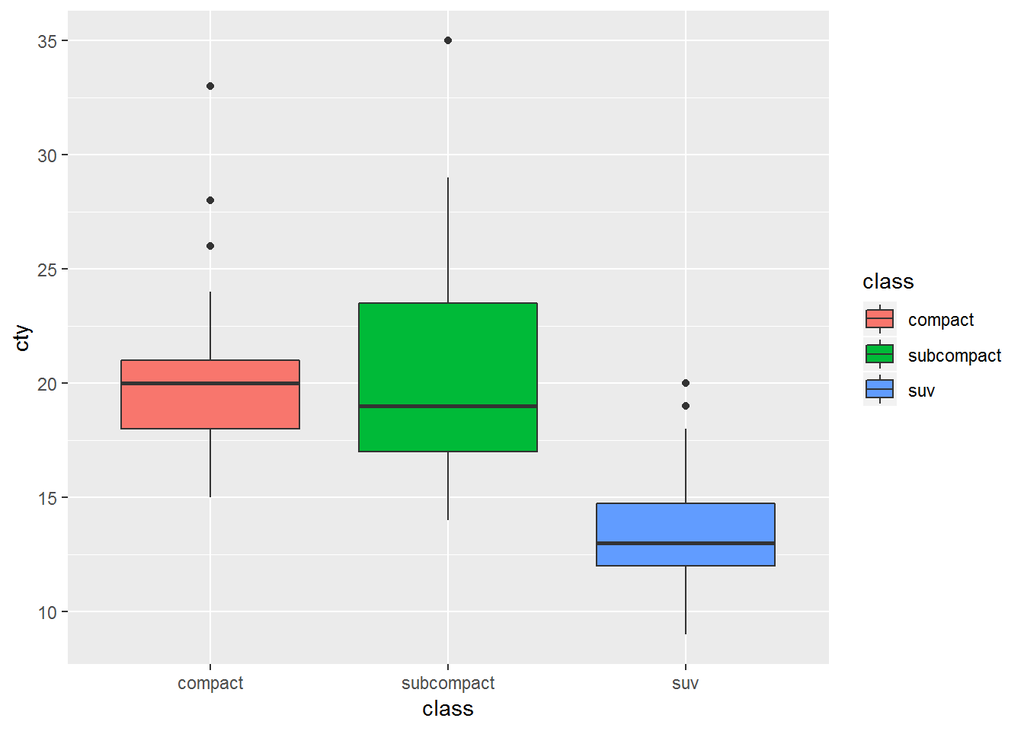

```r
###############
df_3class <- mpg %>%
  filter(class %in% c("compact",'subcompact','suv'))
ggplot(df_3class,aes(x=class,y=cty,fill=class)) + geom_boxplot()
```

#7 Diamonds 데이터 셋을 이용하여 다음 문제를 해결하세요.단, 컬러, 제목, x축, y축 등 그래프를 예쁘게 작성하세요.

#1) cut의 돗수를 보여주는 그래프를 작성하세요.

diamonds_count <- diamonds %>% group_by(cut) %>% count(cut)

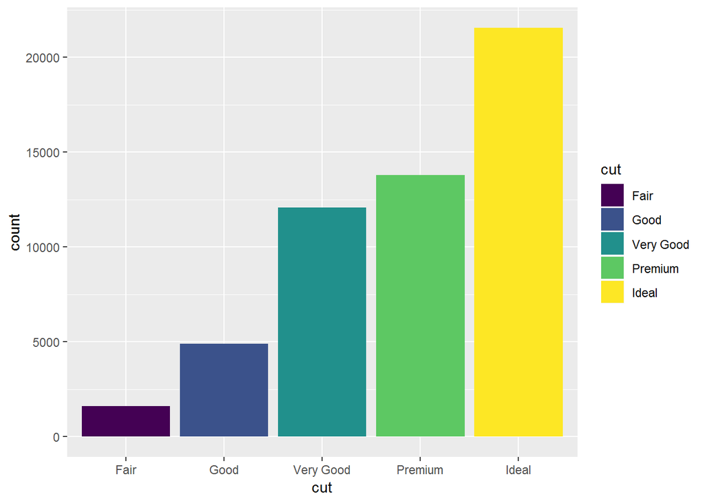

```r
ggplot(diamonds, aes(x = cut,fill=cut)) +
  geom_bar()
```

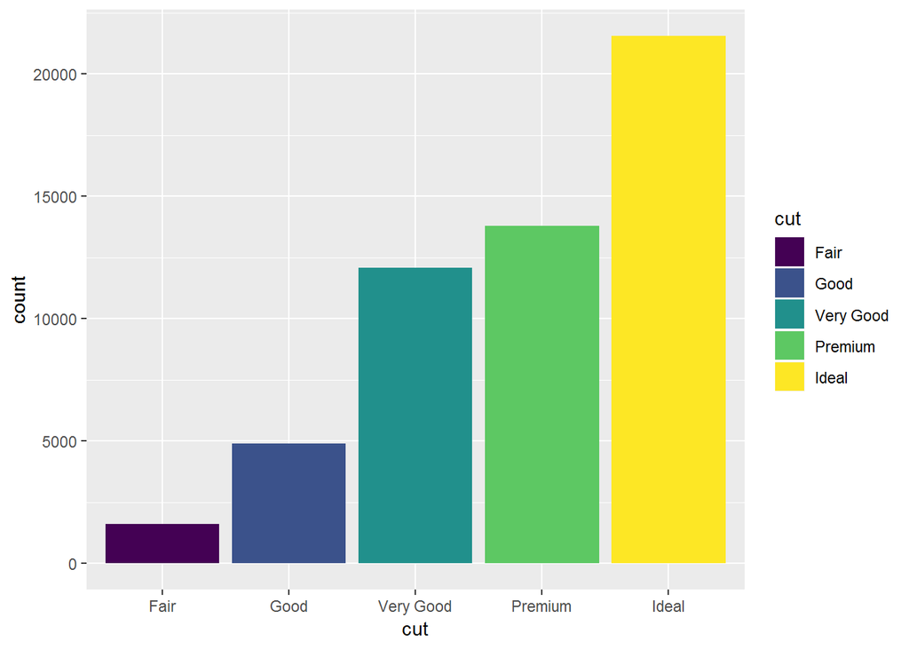

```r
###################################
df_cut <- diamonds %>%
  group_by(cut) %>%
  summarise(count = n())
ggplot(df_cut,aes(x=cut,y=count,fill=cut)) +
  geom_col()
```

#2) cut에 따른 가격의 변화를 보여주는 그래프를 작성하세요.

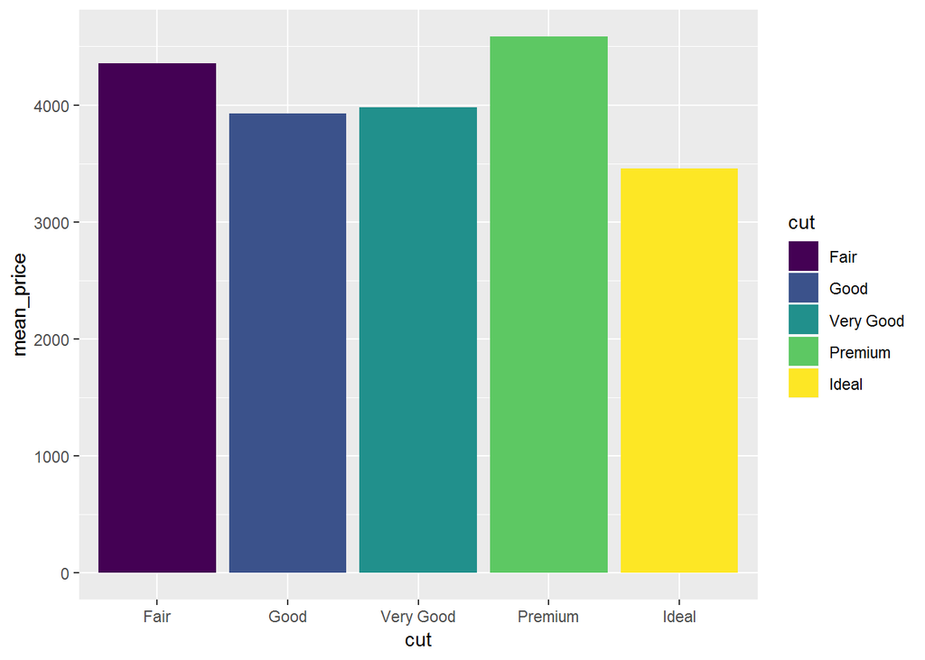

```r
#diamonds_price <- diamonds %>%
#  select(cut,price)
#ggplot(diamonds, aes(x = price,y=cut)) +
#  geom_segment(aes(yend=cut,xend=0),color="blue") +
#  geom_point(size=6,color="green") |
#  theme_bw() +
#  theme(panel.grid.major.y = element_blank() )

df_cut <- diamonds %>%
  group_by(cut) %>%
  summarise(mean_price = mean(price))
ggplot(df_cut, aes(x=cut,y=mean_price, fill=cut)) +
  geom_col()
```

#3) cut과 color에 따른 가격의 변화를 보여주는 그래프를 작성하세요.

[figure not shown]

```r
ggplot(diamonds,aes(x=price)) +
  geom_histogram(bins=10) +
  facet_wrap(~cut + color)
```